# R by Example: Analyzing RECS using Tidyverse (Solution a)

James Henderson, CSCAR

January 30, 2020

## Step 1 - Header and libaries

Before beginning, state your goals and use a header to document our work.

1. Open the template script
2. Update the title, description, author, and date information.
3. Use `library` to add `"tidyverse"` to the search path. Here is an example header.

```r
# R by Example: Analyzing RECS using the Tidyverse
# Solution to participant example (a)
#
# In this script, you will use the 2015 RECS data to examine
# how thermostat behavior impacts the difference between day and night
# temperatures in winter, while someone is home.
#
# Specifically, this sript estimates the national average temperatures, in homes
# that use space heating, during the day when someone is home and at night for
# homes grouped by thermostat behavior.
#
# Data Source:
# https://www.eia.gov/consumption/residential/data/2015/index.php?view=microdata
#
# Updated: January 30, 2020
# Author: James Henderson
# 80: --------------------------------------------------------------------------
```

Always load libraries at the top of your script.

```r
# libraries: -------------------------------------------------------------------
library(tidyverse)
```

## Step 2 - Read data

### Read data

First, read the data using a flag to decide whether to read from the url or a local file.

```r
# data: ------------------------------------------------------------------------
url = paste0(
  'https://www.eia.gov/consumption/residential/data/2015/csv/',
  'recs2015_public_v4.csv'
)
local_file = './recs2015_public_v4.csv'

# use local file if it exists, if not use url and save locally
if ( !file.exists(local_file) ) {
  recs = read_delim(url, delim = ',')
  write_delim(recs, path = local_file, delim = ',')
} else {
  recs = read_delim(local_file, delim = ',')
}
```

## Step 3 - Prepare Data

### Select and format variables

Next, format the data for analysis (as `recs_core`) by selecting key variables and giving them names that are easy for you to remember and type. My convention is to always use `snake_case` and lower case. Below are what the first few rows of the solution look like.

For this section you’ll want to use `transmute()` or `selct()` followed by `mutate()`. To add labels, use `factor()`.

Here are the core variables we’ll need:

- DOEID (`id`)
- NWEIGHT (`weight`)
- HEATHOME (`heat_home`)
- EQUIPMUSE (`therm`)
- TEMPHOME (`temp_home`)
- TEMPNITE (`temp_night`).

```r
# clean up key variables used in this problem: ---------------------------------
#
recs_core =
  recs %>%
  transmute(
    # id variables
    id = DOEID,
    weight = NWEIGHT,
    # grouping factor
    therm = factor(EQUIPMUSE, levels = c(1:5, 9),
             labels = c('Set one temp',
                        'Manually adjust',
                        'Program thermostat',
                        'Turn equipment on/off',
                        'No control',
                        'Other'
                        )
            ),
    # case selection
    heat_home = factor(HEATHOME, 0:1, c('No', 'Yes') ),
    # temp variables
    temp_home = TEMPHOME,
    temp_night = TEMPNITE
  ) %>%
  # Convert negative numbers to missing, for temps.
  mutate_if(is.numeric, function(x) ifelse(x < 0, NA, x))

recs_core
```

```
## # A tibble: 5,686 x 6
##       id weight therm                 heat_home temp_home temp_night
##    <dbl>  <dbl> <fct>                 <fct>         <dbl>      <dbl>
##  1 10001 12085. Program thermostat    Yes              69         60
##  2 10002 14410. Set one temp          Yes              75         72
##  3 10003 23326. Set one temp          Yes              70         68
##  4 10004 12165. Manually adjust       Yes              68         65
##  5 10005 16718. Manually adjust       Yes              68         66
##  6 10006 26059. Turn equipment on/off Yes              70         70
##  7 10007 45953. Manually adjust       Yes              73         72
##  8 10008 15281. Manually adjust       Yes              66         64
##  9 10009 14035. Set one temp          Yes              70         70
## 10 10010 43359. Program thermostat    Yes              70         65
## # … with 5,676 more rows
```

### Filter cases

Reduce `recs_core` to those cases/homes that use space heating in winter.

```r
# filter cases to those that use space heating in winter: ----------------------

## shows why we want to do this, temps are missing if space heating not used
#recs_core %>%
#  filter(heat_home == 'No') %>%
#  summarize_all( .funs = function(x) sum(is.na(x)) )
recs_core = filter(recs_core, heat_home == 'Yes')
```

### Replicate Weights

Finally, set aside the replicate weights for later use and pivot them to a longer format using `pivot_longer()`:

- DOEID (`id`)
- BRRWT1-BRRWT96

```r
# replicate weights, for computing standard errors: ----------------------------
## pivoted to a longer format to facilite dplyr "vectorization"
weights_long =
  recs %>%
  select( id = DOEID, BRRWT1:BRRWT96 ) %>%
  pivot_longer(
    cols = BRRWT1:BRRWT96,
    names_to = 'replicate',
    values_to = 'weight'
  )

weights_long
```

```
## # A tibble: 545,856 x 3
##       id replicate weight
##    <dbl> <chr>      <dbl>
##  1 10001 BRRWT1    16555.
##  2 10001 BRRWT2     5938.
##  3 10001 BRRWT3    17726.
##  4 10001 BRRWT4    17636.
##  5 10001 BRRWT5     6033.
##  6 10001 BRRWT6    17095.
##  7 10001 BRRWT7     6003.
##  8 10001 BRRWT8     5994.
##  9 10001 BRRWT9     5403.
## 10 10001 BRRWT10   17570.
## # … with 545,846 more rows
```

In this analysis, the first step is to form point estimates of the average national day with someone home and night temperatures. Do that by forming weighted (NWEIGHT/`weight`) means of these temperatures (TEMPHOME/`temp_home`, TEMNITE/`temp_night`) by group (EQUIPMUSE/`therm`).

To produce the plot at the end of this analysis, we’ll want the temperatures in a longer format – this is a good time to achieve that using `pivot_longer()`.

```r
# point estimates for winter temperatures by thermostat behavior: --------------

## method 1, manually type out each temperature type
temps_by_therm =
  recs_core %>%
  group_by(therm) %>%
  summarize(
    avg_temp_home = sum(temp_home * weight) / sum(weight),
    avg_temp_night = sum(temp_night * weight) / sum(weight)
  )

## method 2, pivot to a longer format
temps_by_type_therm =
  recs_core %>%
  pivot_longer(
    cols = starts_with('temp'),
    names_to = 'type',
    names_prefix = 'temp_',
    values_to = 'temp'
  ) %>%
  group_by(type, therm) %>%
  summarize( avg_temp = sum(temp * weight) / sum(weight) )

temps_by_type_therm
```

```
## # A tibble: 12 x 3
## # Groups:   type [2]
##    type  therm                 avg_temp
##    <chr> <fct>                    <dbl>
##  1 home  Set one temp              70.3
##  2 home  Manually adjust           70.1
##  3 home  Program thermostat        69.4
##  4 home  Turn equipment on/off     70.0
##  5 home  No control                69.7
##  6 home  Other                     69.5
##  7 night Set one temp              69.5
##  8 night Manually adjust           67.5
##  9 night Program thermostat        66.4
## 10 night Turn equipment on/off     67.3
## 11 night No control                67.9
## 12 night Other                     66.9
```

### Step 5 - Replicate Estimates

Recall that this is survey data and not an identically distributed sample of US households. As such, to estimate standard errors we will use the replicate weights method in which we repeatedly recomptue the estimates from step 4, each time replacing NWEIGHT/`weight` with one of the 96 replicate weights. To do this efficiently:

The result should have rows giving the weighted average temperature for each unique combination of thermostat behavior, temperature type, and set of replicate weights.

```r
# replicate winter temperature estimates, for standard errors: -----------------

## 6 therm values, 2 types, 96 replicate weights = 1152 rows
temps_by_type_therm_repl =
  ### each row is a temperature type for a single home
  recs_core %>%
  select(id, therm, starts_with('temp_') ) %>%
  pivot_longer(
    cols = starts_with('temp'),
    names_to = 'type',
    names_prefix = 'temp_',
    values_to = 'temp'
  ) %>%
  ### join with repliacte weights, each previous row is now 96 rows
  left_join( weights_long, by = c('id') ) %>%
  group_by(type, therm, replicate) %>%
  summarize(  avg_temp_repl = sum(temp * weight) / sum(weight) )
temps_by_type_therm_repl
```

```
## # A tibble: 1,152 x 4
## # Groups:   type, therm [12]
##    type  therm        replicate avg_temp_repl
##    <chr> <fct>        <chr>             <dbl>
##  1 home  Set one temp BRRWT1             70.3
##  2 home  Set one temp BRRWT10            70.3
##  3 home  Set one temp BRRWT11            70.3
##  4 home  Set one temp BRRWT12            70.2
##  5 home  Set one temp BRRWT13            70.2
##  6 home  Set one temp BRRWT14            70.2
##  7 home  Set one temp BRRWT15            70.2
##  8 home  Set one temp BRRWT16            70.3
##  9 home  Set one temp BRRWT17            70.4
## 10 home  Set one temp BRRWT18            70.3
## # … with 1,142 more rows
```

## Step 6 - Standard Errors and confidence bounds

Once we have the replicate estimates for our quantities of interest, we estimate the variance of the point estimates from step 4 using the sum of squared deviations of the replicate estimates around the original point estimates, scaling up by a factor determined in the process of formulating the replicate weights. The standard error is the square root of this variance estimate.

To accomplish this:

1. Join the point estimates from step 4 with the replicate estimates from step 5.
2. Estimate the standard error for each point estimate, using the same grouping structure as used in step 4 to form the point estimates.
3. Add columns `lwr` and `upr` for, respectively, the lower and upper 95% confidence bounds using the point estimate +/- $\Phi^{-1}(.975)$ (or 1.96) times the standard error.

```r
# compute standard errors and CIs: ---------------------------------------------
## 1. Join replicate and point estimates
## 2. Compute std error using scaled RMSE of replicates around point estimates
## 3. Form confidence intervals using standard methods

## Refer to the link below for std error computations, see page 3
## the standard error is the square root of the variance estimate
## https://www.eia.gov/consumption/residential/data/2015/pdf/microdata_v3.pdf

avg_temp_by_type_therm =
 left_join(
   temps_by_type_therm_repl,
   temps_by_type_therm,
   by = c('therm', 'type')
 ) %>%
 group_by(type, therm) %>%
 summarize(
   avg_temp = avg_temp[1], # point estimate: unique(avg_temp), first(avg_temp)
   se = 2 * sqrt( mean( {avg_temp_repl - avg_temp}^2 ) )
 ) %>%
 mutate( lwr = avg_temp - qnorm(.975) * se, upr = avg_temp + qnorm(.975) * se )
```

## Step 7 - Plot the results

Create a plot of the results using ggplot2 and following the template from the example.

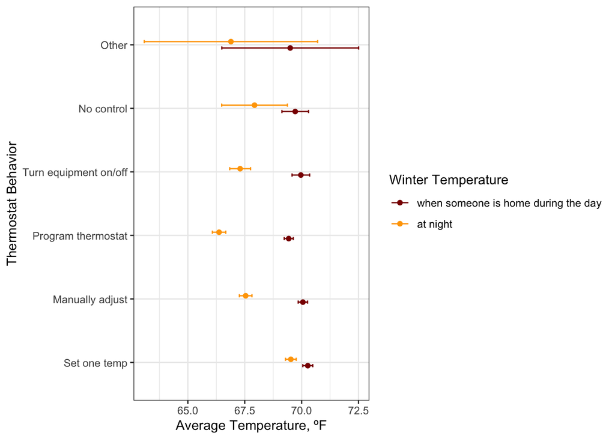

```r
# visualize the results: -------------------------------------------------------
avg_temp_by_type_therm %>%
  mutate( `Winter Temperature` =
            factor(type,
                   levels = c('home', 'night'),
                   labels = c('when someone is home during the day',
                              'at night'
                            )
            )
  ) %>%
  ggplot( aes(y = avg_temp, x = therm, color = `Winter Temperature`) ) +
    geom_point( position = position_dodge(width = 0.2)) +
    geom_errorbar( aes(ymin = lwr, ymax = upr),
                   width = .1, position = position_dodge(width = 0.2)
    ) +
    theme_bw() +
    # w/o coord_flip below, may want to rotate labels
    #theme( axis.text.x = element_text(angle = 90) ) +
    xlab('Thermostat Behavior') +
    ylab('Average Temperature, ºF') +
    scale_color_manual( values = c("darkred", "orange") ) +
    coord_flip()
```